# Introduction to R

This is an RMarkdown file. It mixes code and text. We can compile it into an HTML that contains everything. To compile it, click on “Knit”.

We can execute a chuck of code by `Ctrl+Shift+Enter` (Windows) or `Command+Shift+Enter` (macOS).

See a list of shortcuts [here](https://bookdown.org/yihui/rmarkdown-cookbook/rstudio-shortcuts.html).

## Download R and Rstudio

https://cran.r-project.org/bin/windows/base/ (Windows)

https://cran.r-project.org/bin/macosx/ (macOS)

https://www.rstudio.com/products/rstudio/download/

## R basics

Everything is stored as a variable. It’s different from SPSS in this respect. We can see all the variables in the “Environment”. To assign something to a variable, use `<-`

```r
result <- 1+1
```

To view a variable

```r
result
```

```
## [1] 2
```

```r
View(result)
```

|  | R | Python |
| --- | --- | --- |
| Addition | + | + |
| Subtraction | - | - |
| Multiplication | * | * |
| Division | / | / |
| Exponentiation | ^ | ** |
| Variable assignment | <- | = |

To check data type

```r
class(result)
```

```
## [1] "numeric"
```

|  | R | Python |
| --- | --- | --- |
| 200 | integer | int |
| 200.15 | numeric | float |
| TRUE / FALSE | logical | bool (True / False) |
| “lit review” | character | str |
| To check data type | `class()` | `type()` |

Logical comparison:

< less than  
> greater than  
<= less than or equal to  
>= greater than or equal to  
== equal to  
!= not equal to

## Load packages

```r
library(haven) # read data in SPSS, SAS or Stata formats
library(dplyr) # data wrangling
```

```r
library(ggplot2) # plots
```

The libraries are loaded successfully if there’s no error message. Warnings are usually harmless. Pay attention to the conflicts.

## Import data

```r
soss <- read_sav("./SOSS81Data.sav")
```

```r
#View(soss)
soss
```

```
## # A tibble: 1,000 x 348
##        caseid weight REGNRACE SEXAGEWT ADJWT MSUEWT STATEWT EADJWT EMSUEWT
##         <dbl>  <dbl>    <dbl>    <dbl> <dbl>  <dbl>   <dbl>  <dbl>   <dbl>
##  1 1394809595  0.331    1.13     1.41  1.41   1.41    1.39   0.962   0.947
##  2 1394834017  0.551    0.878    0.509 0.509  0.511   0.502  0.382   0.376
##  3 1394835239  1.28     0.613    1.26  1.26   1.27    1.28   1.00    0.990
##  4 1394813219  0.925    0.878    0.591 0.591  0.593   0.583  0.518   0.510
##  5 1394853595  1.01     1.10     0.640 0.640  0.642   0.647  0.451   0.444
##  6 1394834859  0.555    1.10     0.744 0.744  0.746   0.752  1.10    1.08
##  7 1394863425  1.09     0.726    0.575 0.575  0.577   0.564  0.416   0.410
##  8 1394866883  0.583    0.878    0.901 0.901  0.904   0.889  0.699   0.688
##  9 1394849645  0.562    0.878    1.78  1.78   1.78    1.75   1.38    1.36
## 10 1394822399  0.931    0.726    0.421 0.421  0.422   0.412  0.295   0.290
## # … with 990 more rows, and 339 more variables: ESTATEWT <dbl>,
## #   mcan3_split <dbl+lbl>, legal102_split <dbl+lbl>,
## #   ippsr01_split <dbl+lbl>, inputzip <dbl>, CC1 <dbl+lbl>, CC2 <dbl+lbl>,
## #   CC3 <dbl+lbl>, CC4 <dbl+lbl>, CC5 <dbl+lbl>, CC6 <dbl+lbl>, A1 <chr>,
## #   PO1 <dbl+lbl>, PO2 <dbl+lbl>, D10 <dbl+lbl>, D11 <dbl+lbl>,
## #   D12 <dbl+lbl>, P4a <chr>, CD10 <dbl+lbl>, CD11 <dbl+lbl>,
## #   UN1 <dbl+lbl>, UN2 <dbl+lbl>, UN3 <dbl+lbl>, X1 <dbl+lbl>, X1_t <chr>,
## #   demo_county <dbl+lbl>, demo_Detroit <dbl+lbl>, cellular2 <chr>,
## #   legsal01 <dbl+lbl>, mcan1 <dbl+lbl>, mcan2 <dbl+lbl>,
## #   mcan3a <dbl+lbl>, mcan4a <dbl+lbl>, mcan3b <dbl+lbl>,
## #   mcan4b <dbl+lbl>, kennedy01 <dbl+lbl>, kennedy01a_1 <dbl+lbl>,
## #   kennedy01a_2 <dbl+lbl>, kennedy01a_3 <dbl+lbl>,
## #   kennedy01a_4 <dbl+lbl>, kennedy01a_5 <dbl+lbl>, kennedy01a_t <chr>,
## #   kennedy01b_1 <dbl+lbl>, kennedy01b_2 <dbl+lbl>,
## #   kennedy01b_3 <dbl+lbl>, kennedy01b_4 <dbl+lbl>,
## #   kennedy01b_5 <dbl+lbl>, kennedy01b_6 <dbl+lbl>,
## #   kennedy01b_7 <dbl+lbl>, kennedy01b_8 <dbl+lbl>,
## #   kennedy01b_9 <dbl+lbl>, kennedy01b_t <chr>, kennedy01c_1 <dbl+lbl>,
## #   kennedy01c_2 <dbl+lbl>, kennedy01c_3 <dbl+lbl>,
## #   kennedy01d_1 <dbl+lbl>, kennedy01d_2 <dbl+lbl>,
## #   kennedy01d_3 <dbl+lbl>, kennedy01d_4 <dbl+lbl>,
## #   kennedy01d_5 <dbl+lbl>, kennedy01d_t <chr>, kennedy02 <dbl+lbl>,
## #   kennedy02a_1 <dbl+lbl>, kennedy02a_2 <dbl+lbl>,
## #   kennedy02a_3 <dbl+lbl>, kennedy02a_4 <dbl+lbl>,
## #   kennedy02a_5 <dbl+lbl>, kennedy02a_t <chr>, kennedy02b_1 <dbl+lbl>,
## #   kennedy02b_2 <dbl+lbl>, kennedy02b_3 <dbl+lbl>,
## #   kennedy02b_4 <dbl+lbl>, kennedy02b_5 <dbl+lbl>,
## #   kennedy02b_6 <dbl+lbl>, kennedy02b_7 <dbl+lbl>,
## #   kennedy02b_8 <dbl+lbl>, kennedy02b_9 <dbl+lbl>, kennedy02b_t <chr>,
## #   kennedy02c_1 <dbl+lbl>, kennedy02c_2 <dbl+lbl>,
## #   kennedy02c_3 <dbl+lbl>, kennedy03_a <dbl+lbl>, kennedy03_b <dbl+lbl>,
## #   kennedy03_c <dbl+lbl>, kennedy03_d <dbl+lbl>, kennedy03_e <dbl+lbl>,
## #   kennedy04 <dbl+lbl>, kennedy05 <dbl+lbl>, kennedy06 <dbl+lbl>,
## #   kennedy07_1 <dbl+lbl>, kennedy07_2 <dbl+lbl>, kennedy07_3 <dbl+lbl>,
## #   kennedy07_4 <dbl+lbl>, kennedy07_5 <dbl+lbl>, kennedy07_6 <dbl+lbl>,
## #   kennedy07_7 <dbl+lbl>, kennedy07_8 <dbl+lbl>, kennedy07_9 <dbl+lbl>,
## #   kennedy07_10 <dbl+lbl>, kennedy07_11 <dbl+lbl>, …
```

## Data wrangling

To select columns we need

```r
df <- soss %>% select(caseid, weight, driving18, driving19, driving20, driving21, driving22a, driving22b, driving22c, driving23a, driving23b, driving23c, driving16, driving17, CD1, age, agecat7, CD5a, races, rac3, educat4, laborforce, inc, X1, X1_t, driving01)
```

`%>%` (`Ctrl+Shift+M` or `Command+Shift+M`) is called “pipe”. It chains functions together by passing the left hand side of the operator to the first argument of the right hand side of the operator. In the above chain, `soss` is passed to `select()`, and then the result of that is saved to `df`.

```r
df %>% head()
```

```
## # A tibble: 6 x 26
##    caseid weight    driving18   driving19  driving20   driving21 driving22a
##     <dbl>  <dbl>    <dbl+lbl>   <dbl+lbl>  <dbl+lbl>   <dbl+lbl>  <dbl+lbl>
## 1  1.39e9  0.331 2 [Somewhat… 2 [Somewha… 2 [Somewh…  3 [Somewh… 4 [N/A]
## 2  1.39e9  0.551 2 [Somewhat… 2 [Somewha… 2 [Somewh… NA          3 [Less l…
## 3  1.39e9  1.28  2 [Somewhat… 2 [Somewha… 2 [Somewh…  2 [Somewh… 3 [Less l…
## 4  1.39e9  0.925 3 [Somewhat… 4 [Very un… 4 [Very u…  4 [Very u… 4 [N/A]
## 5  1.39e9  1.01  1 [Very com… 1 [Very co… 1 [Very c…  1 [Very c… 4 [N/A]
## 6  1.39e9  0.555 4 [Very unc… 4 [Very un… 4 [Very u…  4 [Very u… 4 [N/A]
## # … with 19 more variables: driving22b <dbl+lbl>, driving22c <dbl+lbl>,
## #   driving23a <dbl+lbl>, driving23b <dbl+lbl>, driving23c <dbl+lbl>,
## #   driving16 <dbl+lbl>, driving17 <dbl+lbl>, CD1 <dbl+lbl>, age <dbl>,
## #   agecat7 <dbl+lbl>, CD5a <dbl+lbl>, races <dbl+lbl>, rac3 <dbl+lbl>,
## #   educat4 <dbl+lbl>, laborforce <dbl+lbl>, inc <dbl+lbl>, X1 <dbl+lbl>,
## #   X1_t <chr>, driving01 <dbl+lbl>
```

To select rows

```r
df %>% filter(age <= 20)
```

```
## # A tibble: 22 x 26
##     caseid weight   driving18   driving19   driving20  driving21 driving22a
##      <dbl>  <dbl>   <dbl+lbl>   <dbl+lbl>   <dbl+lbl>  <dbl+lbl>  <dbl+lbl>
##  1  1.39e9  0.350 3 [Somewha… 2 [Somewha… 2 [Somewha… 4 [Very u… 2 [Equall…
##  2  1.40e9  3.63  2 [Somewha… 2 [Somewha… 2 [Somewha… 2 [Somewh… 3 [Less l…
##  3  1.40e9  3.44  1 [Very co… 4 [Very un… 3 [Somewha… 2 [Somewh… 4 [N/A]
##  4  1.40e9  4.56  4 [Very un… 3 [Somewha… 4 [Very un… 3 [Somewh… 2 [Equall…
##  5  1.40e9  2.07  1 [Very co… 2 [Somewha… 3 [Somewha… 3 [Somewh… 1 [More l…
##  6  1.40e9  2.07  3 [Somewha… 3 [Somewha… 2 [Somewha… 4 [Very u… 1 [More l…
##  7  1.40e9  3.12  1 [Very co… 3 [Somewha… 1 [Very co… 2 [Somewh… 2 [Equall…
##  8  1.40e9  4.91  1 [Very co… 1 [Very co… 1 [Very co… 1 [Very c… 4 [N/A]
##  9  1.40e9  0.845 2 [Somewha… 2 [Somewha… 1 [Very co… 1 [Very c… 3 [Less l…
## 10  1.40e9  0.836 1 [Very co… 1 [Very co… 1 [Very co… 1 [Very c… 4 [N/A]
## # … with 12 more rows, and 19 more variables: driving22b <dbl+lbl>,
## #   driving22c <dbl+lbl>, driving23a <dbl+lbl>, driving23b <dbl+lbl>,
## #   driving23c <dbl+lbl>, driving16 <dbl+lbl>, driving17 <dbl+lbl>,
## #   CD1 <dbl+lbl>, age <dbl>, agecat7 <dbl+lbl>, CD5a <dbl+lbl>,
## #   races <dbl+lbl>, rac3 <dbl+lbl>, educat4 <dbl+lbl>,
## #   laborforce <dbl+lbl>, inc <dbl+lbl>, X1 <dbl+lbl>, X1_t <chr>,
## #   driving01 <dbl+lbl>
```

To re-order the dataset

```r
df %>% arrange(inc) # by income (from less to more)
```

```
## # A tibble: 1,000 x 26
##     caseid weight   driving18   driving19   driving20  driving21 driving22a
##      <dbl>  <dbl>   <dbl+lbl>   <dbl+lbl>   <dbl+lbl>  <dbl+lbl>  <dbl+lbl>
##  1  1.39e9  0.551  2 [Somewh… 2 [Somewha…  2 [Somewh… NA         3 [Less l…
##  2  1.39e9  0.834  1 [Very c… 1 [Very co…  4 [Very u…  2 [Somew… 4 [N/A]
##  3  1.39e9  0.350  3 [Somewh… 2 [Somewha…  2 [Somewh…  4 [Very … 2 [Equall…
##  4  1.39e9  0.490  2 [Somewh… 2 [Somewha…  2 [Somewh…  2 [Somew… 3 [Less l…
##  5  1.40e9  0.772  2 [Somewh… 2 [Somewha… NA           2 [Somew… 4 [N/A]
##  6  1.39e9  0.599  2 [Somewh… 2 [Somewha…  1 [Very c…  2 [Somew… 4 [N/A]
##  7  1.39e9  0.522  1 [Very c… 3 [Somewha…  2 [Somewh…  1 [Very … 4 [N/A]
##  8  1.39e9  0.646  4 [Very u… 4 [Very un…  3 [Somewh…  4 [Very … 4 [N/A]
##  9  1.40e9  0.805 NA          1 [Very co…  1 [Very c…  1 [Very … 3 [Less l…
## 10  1.40e9  1.11   2 [Somewh… 2 [Somewha…  2 [Somewh…  2 [Somew… 3 [Less l…
## # … with 990 more rows, and 19 more variables: driving22b <dbl+lbl>,
## #   driving22c <dbl+lbl>, driving23a <dbl+lbl>, driving23b <dbl+lbl>,
## #   driving23c <dbl+lbl>, driving16 <dbl+lbl>, driving17 <dbl+lbl>,
## #   CD1 <dbl+lbl>, age <dbl>, agecat7 <dbl+lbl>, CD5a <dbl+lbl>,
## #   races <dbl+lbl>, rac3 <dbl+lbl>, educat4 <dbl+lbl>,
## #   laborforce <dbl+lbl>, inc <dbl+lbl>, X1 <dbl+lbl>, X1_t <chr>,
## #   driving01 <dbl+lbl>
```

```r
#df %>% arrange(desc(inc)) # from more to less
```

```r
#soss$CD1 %>% attr("labels")
unique(soss$CD1)
```

```
## <labelled<double>[4]>: Sex
## [1]  2  1  3 NA
##
## Labels:
##  value          label
##      1           Male
##      2         Female
##      3 Intersex/Other
##      8        skipped
##      9      not asked
```

```r
df %>% count(CD1)
```

```
## # A tibble: 4 x 2
##                   CD1     n
##             <dbl+lbl> <int>
## 1  1 [Male]             439
## 2  2 [Female]           555
## 3  3 [Intersex/Other]     5
## 4 NA                      1
```

To create a new variable

```r
df %>% mutate(gender = as.factor(CD1))
```

```
## # A tibble: 1,000 x 27
##     caseid weight   driving18   driving19   driving20  driving21 driving22a
##      <dbl>  <dbl>   <dbl+lbl>   <dbl+lbl>   <dbl+lbl>  <dbl+lbl>  <dbl+lbl>
##  1  1.39e9  0.331 2 [Somewha… 2 [Somewha… 2 [Somewha…  3 [Somew… 4 [N/A]
##  2  1.39e9  0.551 2 [Somewha… 2 [Somewha… 2 [Somewha… NA         3 [Less l…
##  3  1.39e9  1.28  2 [Somewha… 2 [Somewha… 2 [Somewha…  2 [Somew… 3 [Less l…
##  4  1.39e9  0.925 3 [Somewha… 4 [Very un… 4 [Very un…  4 [Very … 4 [N/A]
##  5  1.39e9  1.01  1 [Very co… 1 [Very co… 1 [Very co…  1 [Very … 4 [N/A]
##  6  1.39e9  0.555 4 [Very un… 4 [Very un… 4 [Very un…  4 [Very … 4 [N/A]
##  7  1.39e9  1.09  2 [Somewha… 2 [Somewha… 2 [Somewha…  3 [Somew… 4 [N/A]
##  8  1.39e9  0.583 2 [Somewha… 3 [Somewha… 2 [Somewha…  2 [Somew… 2 [Equall…
##  9  1.39e9  0.562 4 [Very un… 4 [Very un… 4 [Very un…  4 [Very … 4 [N/A]
## 10  1.39e9  0.931 2 [Somewha… 2 [Somewha… 2 [Somewha…  2 [Somew… 3 [Less l…
## # … with 990 more rows, and 20 more variables: driving22b <dbl+lbl>,
## #   driving22c <dbl+lbl>, driving23a <dbl+lbl>, driving23b <dbl+lbl>,
## #   driving23c <dbl+lbl>, driving16 <dbl+lbl>, driving17 <dbl+lbl>,
## #   CD1 <dbl+lbl>, age <dbl>, agecat7 <dbl+lbl>, CD5a <dbl+lbl>,
## #   races <dbl+lbl>, rac3 <dbl+lbl>, educat4 <dbl+lbl>,
## #   laborforce <dbl+lbl>, inc <dbl+lbl>, X1 <dbl+lbl>, X1_t <chr>,
## #   driving01 <dbl+lbl>, gender <fct>
```

```r
df %>% filter(age <= 20) %>% group_by(inc) %>% count()
```

```
## # A tibble: 8 x 2
## # Groups:   inc [8]
##                         inc     n
##                   <dbl+lbl> <int>
## 1  1 [Less than $10,000]        3
## 2  2 [$10,000 to $19,999]       3
## 3  3 [$20,000 to $29,999]       2
## 4  4 [$30,000 to $39,999]       2
## 5  5 [$40,000 to $49,999]       1
## 6  6 [$50,000 to $59,999]       5
## 7  8 [$70,000 to $89,999]       4
## 8 10 [$100,000 to $149,999]     2
```

```r
#df$inc %>% attr("labels")
```

## Virtualization

There are several ways to draw plots in R. `base graphics` is built in R. `ggplot2` looks better. `plotly` is gaining popularity.

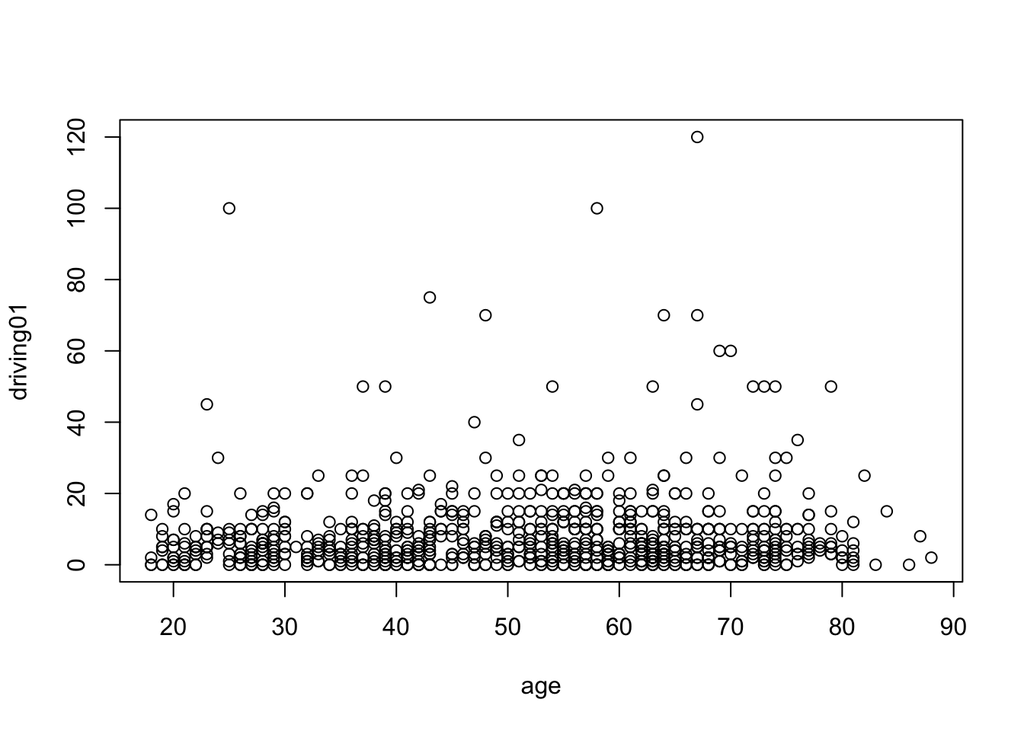

```r
# base graphics
plot(driving01 ~ age,data  = df) # hours of driving by age
```

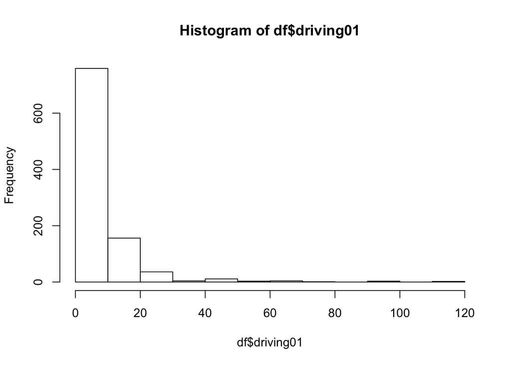

```r
hist(df$driving01)
```

```
## Warning: Removed 193 rows containing missing values (geom_point).
```

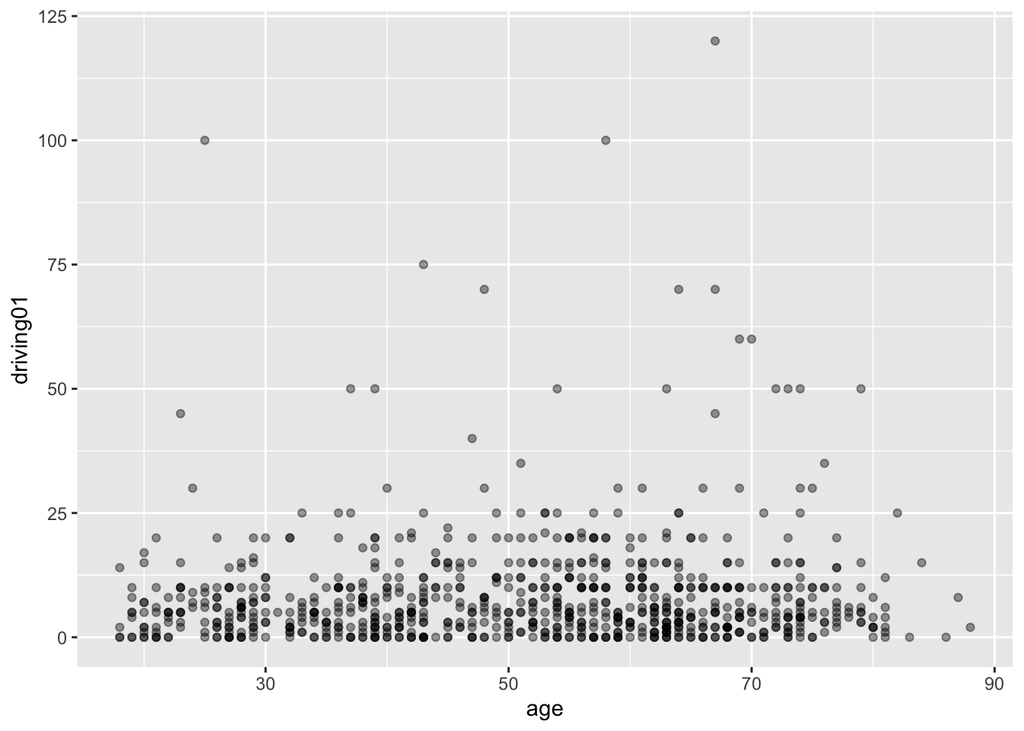

```r
ggplot(data = df) +
  geom_point(aes(x=age, y=driving01), alpha=0.4)
```

Notice the warnings. It is because we haven’t clean the data properly. Let’s ignore it for now.

```
## Warning: Removed 193 rows containing missing values (geom_point).
```

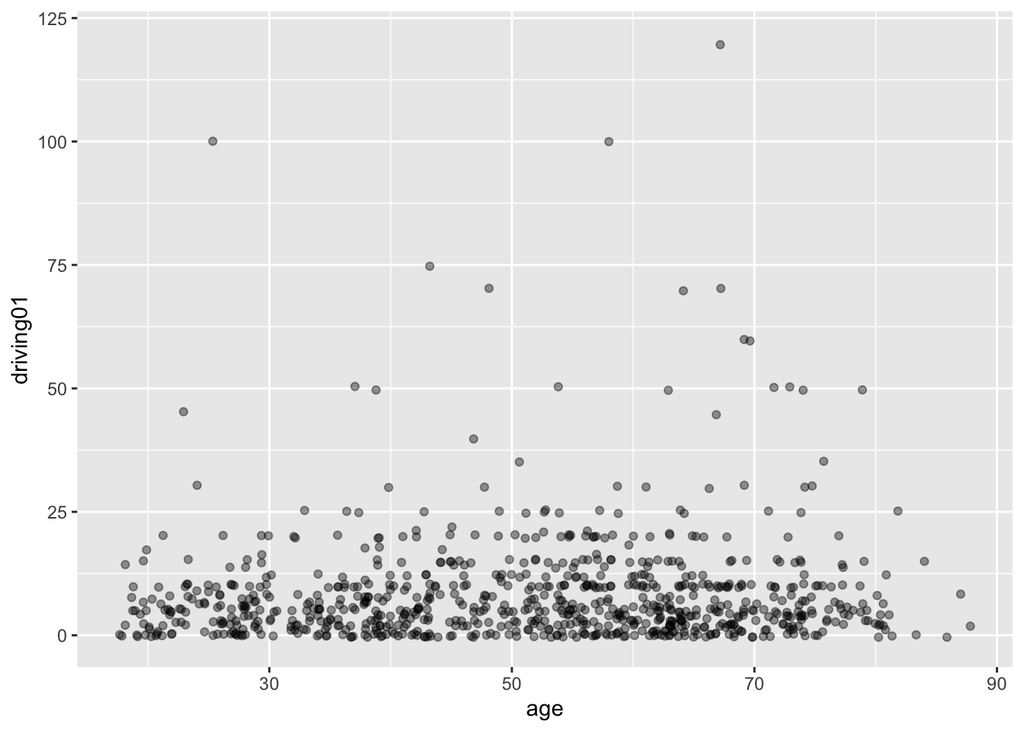

```r
ggplot(data = df) +
  geom_jitter(aes(x=age, y=driving01), alpha=0.4)
```

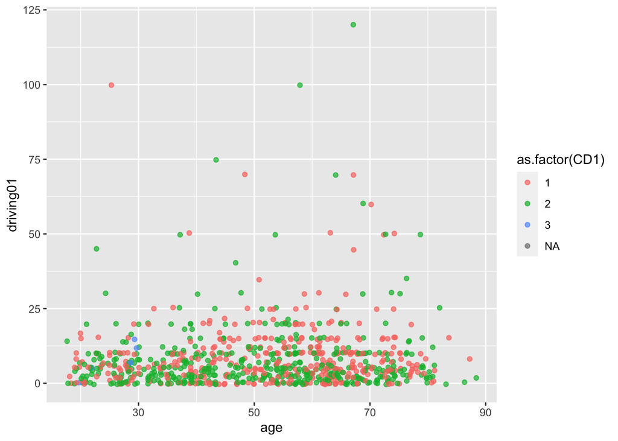

```r
ggplot(data = df) +
  geom_jitter(aes(x=age, y=driving01, color=as.factor(CD1)), alpha=0.7)
```

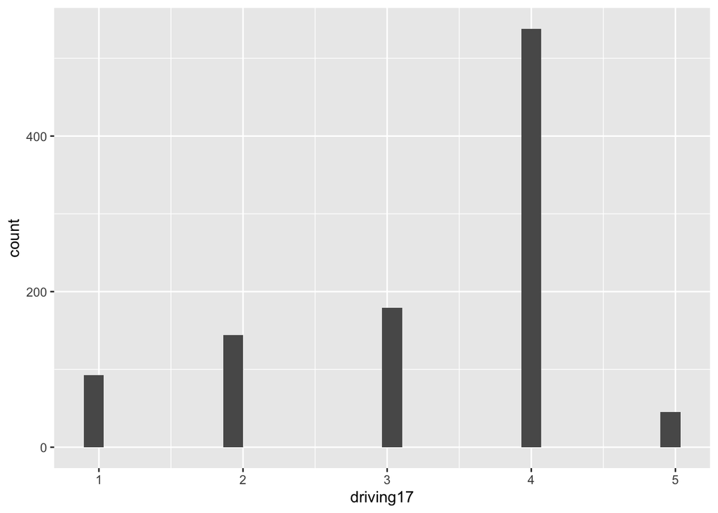

```r
ggplot(df) +
  geom_histogram(aes(x=driving17)) #Interest in owning or leasing an AV
```

```r
#unique(df$driving17)
```

## Clean the SOSS data

```r
#gender: 0=male, 1=female
df <- df %>% mutate(gender = as.factor(CD1))
df$gender[df$gender==3] <- NA
df$gender[df$gender==8] <- NA
df$gender[df$gender==9] <- NA
df$gender <- recode(df$gender,`1`= 0, `2`=1)

#age: continuous
df <- df %>% mutate(age=as.numeric(age))
#agec:1=18-29, 2=30-39, 3=40-49, 4=50-59, 5=60-69, 6=70-79, 7=80+
df <- df %>% mutate(agec=as.factor(agecat7))
```

## Respondents profile (unweighted)

```r
df %>% group_by(gender) %>% summarize(n=n()) %>% mutate(freq=round((n/sum(n)*100),2))
```

```
## # A tibble: 3 x 3
##   gender     n  freq
##    <dbl> <int> <dbl>
## 1      0   439  43.9
## 2      1   555  55.5
## 3     NA     6   0.6
```

Or we can write a function

```r
profile <- function(data,variable){
  data %>% group_by({{variable}}) %>% summarize(n=n()) %>% mutate(freq=round((n/sum(n)*100),2))
  }
```

```r
profile(df, agec)
```

```
## # A tibble: 8 x 3
##   agec      n  freq
##   <fct> <int> <dbl>
## 1 1       120  12
## 2 2       115  11.5
## 3 3       126  12.6
## 4 4       166  16.6
## 5 5       176  17.6
## 6 6        99   9.9
## 7 7        19   1.9
## 8 <NA>    179  17.9
```

To exclude NA

```r
df %>% filter(!is.na(agec)) %>%  group_by(agec) %>% summarize(n=n()) %>% mutate(freq=round((n/sum(n)*100),2))
```

```
## # A tibble: 7 x 3
##   agec      n  freq
##   <fct> <int> <dbl>
## 1 1       120 14.6
## 2 2       115 14.0
## 3 3       126 15.4
## 4 4       166 20.2
## 5 5       176 21.4
## 6 6        99 12.1
## 7 7        19  2.31
```

## Respondents profile (weighted)

```r
library(survey)
```

Documentation: https://cran.r-project.org/web/packages/survey/survey.pdf

```r
w <- svydesign(ids = ~1, data= df, weights = df$weight)
```

```r
data.frame(prop.table(svytable(~agec, design = w)))%>% mutate(n=round(Freq*length(which(!is.na(df$agec)))), percentage=round((Freq*100),2))
```

```
##   agec       Freq   n percentage
## 1    1 0.22029675 181      22.03
## 2    2 0.13667264 112      13.67
## 3    3 0.14283824 117      14.28
## 4    4 0.18676321 153      18.68
## 5    5 0.18592748 153      18.59
## 6    6 0.10648377  87      10.65
## 7    7 0.02101791  17       2.10
```